# **Club Football Match Analysis**

[figure not shown]

L'idea di base e' quella di capire come sia evoluto il calcio negli ultimi 25 anni, evidentemente il modo di giocare e' cambiato tanto negli anni, ma per capire se questi cambiamenti, cosi' come le nuove regole, l'introduzione del VAR, abbiano avuto un impatto sui risultati bisogna analizzare i dati📊

# Il DataSet

Il seguente progetto e' stato realizzato su un DataSet pubblico, disponibile sul web, contenete informazioni su partite di calcio dal 2000 al 2024, tra le quali:

- **Data dell'incontro**: la data in cui la partita e' stata giocata,
- **Risultato finale**: il punteggio finale della partita,
- **Coefficiente Elo**: coefficente che misura la forza di una squadra in base ai risultati precedenti.

Non sono presenti nel DataSet i dati sul numero di spettatori presenti allo stadio che potrebbe essere un fattore importante da analizzare.

E' stato creato da Adam Gábor nel dicembre 2024 e modificato per l'ultima volta a gennaio 2025

# Analisi e Pulizia del DataSet

In questa prima parte mi concentro sul numero di partite presente nel nostro DataSet: Dopo aver eliminato le partite in cui manca il risultato, inizio l'analisi dei dati, in particolare mi concentro sul numero di partite.

Ragruppo le partite per anno e per campionato; vediamo i grafici nella prossima slide

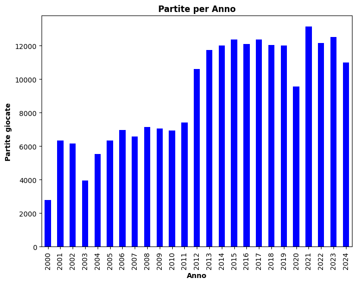

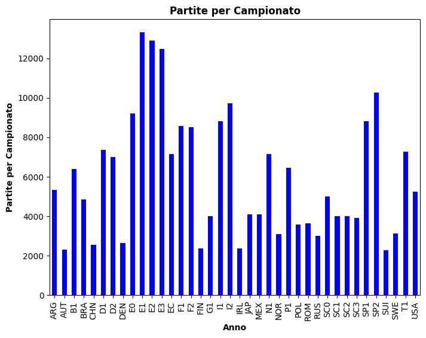

# Numero di gol

Dopo aver capito come fossero organizzati i dati nel DataSet, mi focalizzo sul numero di gol realizzati: In particolare analizzo:

-**Gol segnati**: la quantita' di reti registrate durante un anno,

-**Media gol**: la quantita' **media** di gol segnati durante un anno,

-**Distrubuzione numero di gol**:frequenza con cui si verifica una certa quantita' di reti.

Analizzo anche se esistono delle diferenze nella quantita' media dei gol segnati nei campionati piu' importanti e in quelli secondari

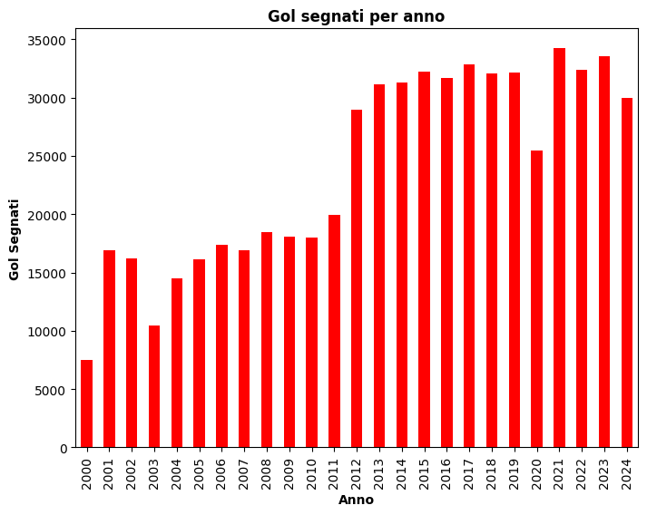

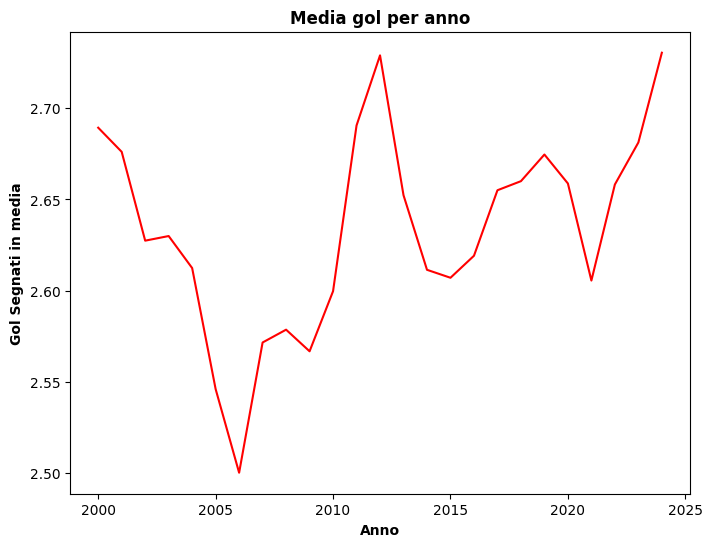

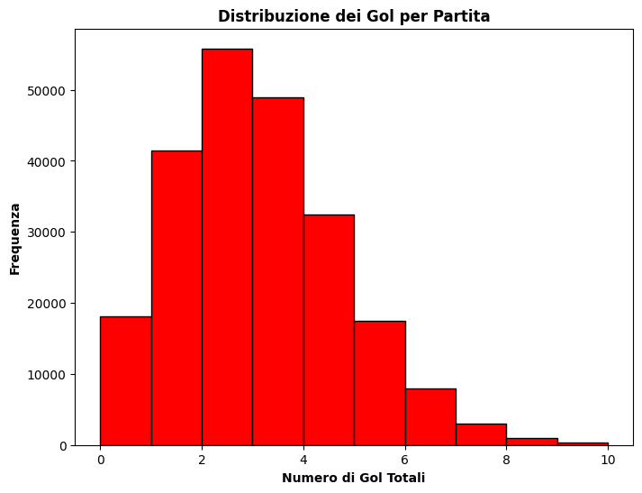

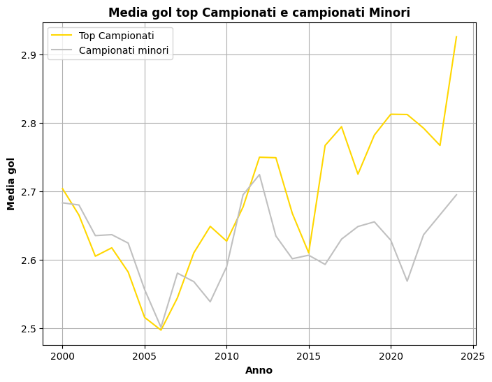

# L'orario influisce sul risultato?🤔

Mi concentro sull'orario di inizio delle partite; in particolare creo una funzione che in base all'orario di inizio stabilisce se la partita e' stata giocata durante la mattina, il pomeriggio e durante la sera.

Le fasce che ho determinato sono:

-**Mattina**:(6-12)

-**Pomeriggio**:[12-18)

-**Sera**:[18-23:59)

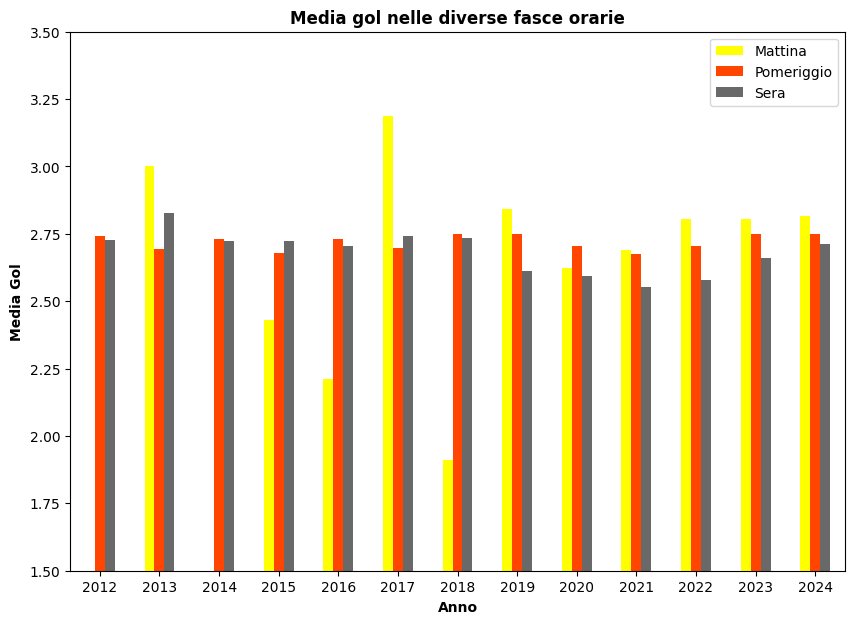

# Coefficente Elo

Il coefficente elo e' un metodo matematico che consente di determinare la forma di una squadra in un certo periodo, a seconda dei risultati ottenuti sul campo, voglio capire quanto sia affidabile questo indicatore, andando ad analizzare i risultati delle squadre favorite secondo il coefficente. La formula per il calcolo e' la seguente:

Rn = Ro + K × (W - We)

Dove "Rn" e' il coefficente aggiornato, "Ro" e' il coefficente precedente (prima dell'ultime partita), "K" e' una costante che rappresenta il coefficente di difficolta' della partita(varia a seconda del tipo di partita), "W" corrisponde al risultato della partita(vale 1 se la squadra vince, 0.5 se pareggia e 0 in caso di sconfitta), "We" infine prende il nome di risultato atteso e si calcola come: We = 1 / (10^(-dr/400) + 1), dove dr e' la differenza dei coefficenti tra le due squadre.

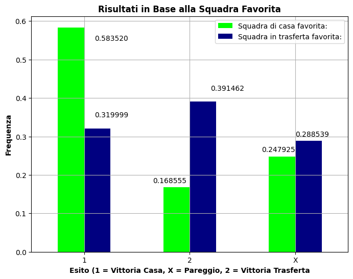

# Conclusioni

L'analisi di questi dati mi ha permesso di capire come il calcio sia camiato negli ultimi anni, mi ha fatto scoprire l'esistenza del coefficente elo di cui prima non ero a conoscenza,e che rappresenta una valida stima della forza di una squadra.

Le principali conclusioni che posso trarre dall'analisi dei dati sono:

-Si segna di piu' mediamente oggi rispetto al passato, questo fatto potevo aspettarmelo in quanto prima la maggior parte delle squadre avevano un modo di giocare piu' difensivo e si lavorava molto di meno sulla parte tattica e fisica,

-L'introduzione di regole piu' restrittive per quanto riguarda il fuorigioco ha causato una significativa diminuzione dei gil segnati mediamente, soprattutto all'inizio,

-Oggi si segna molto di piu' nei campionati principali rispetto a quelli secondari, in passato la differenza era molto minore,

-Negli ultimi anni si segna di piu' nelle partite giocate nella mattina/pomeriggio rispetto alle partite giocate la sera